# Practical Machine Learning Course Project

Florian Süßer

Juni 2015

Without further hesitation, I remove all columns which contain no data, NAs and are not of relevance. We want to use only behavioural data to predict right/wrong exercises. The first seven columns seem to indicate formal details about the experiment such as time, subject and setting. Let us just briefly see if there is a difference between the subjects: qplot(data = training, x = user_name, fill = classe)

```r
#setwd("coursera/")
library(caret)
```

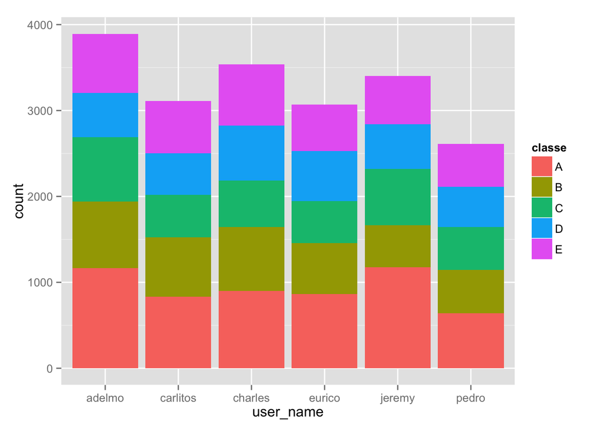

```r
library(data.table) #caret seems to have difficulties with data.table
training <- read.csv("pml-training.csv")
qplot(data = training, x = user_name, fill = classe)
```

The subjects seem to vary slightly in the amounts of different exercises they did but here we clearly see that there is probably no bias produced through the different subjects. Also, we do not really want to use the user_name variable for prediction anyway.

There also seem to be various columns with no values and with NAs. We remove these as well:

```r
training <- training[, -c(1, 2, 3, 4, 5, 6, 7)]

na_values <- apply(training, 2, function(x){sum(is.na(x))}) #see whether columns contain many NAs
na_columns <- which(na_values > 0)
na_columns
```

```
##            max_roll_belt           max_picth_belt            min_roll_belt
##                       11                       12                       14
##           min_pitch_belt      amplitude_roll_belt     amplitude_pitch_belt
##                       15                       17                       18
##     var_total_accel_belt            avg_roll_belt         stddev_roll_belt
##                       20                       21                       22
##            var_roll_belt           avg_pitch_belt        stddev_pitch_belt
##                       23                       24                       25
##           var_pitch_belt             avg_yaw_belt          stddev_yaw_belt
##                       26                       27                       28
##             var_yaw_belt            var_accel_arm             avg_roll_arm
##                       29                       43                       44
##          stddev_roll_arm             var_roll_arm            avg_pitch_arm
##                       45                       46                       47
##         stddev_pitch_arm            var_pitch_arm              avg_yaw_arm
##                       48                       49                       50
##           stddev_yaw_arm              var_yaw_arm             max_roll_arm
##                       51                       52                       68
##            max_picth_arm              max_yaw_arm             min_roll_arm
##                       69                       70                       71
##            min_pitch_arm              min_yaw_arm       amplitude_roll_arm
##                       72                       73                       74
##      amplitude_pitch_arm        amplitude_yaw_arm        max_roll_dumbbell
##                       75                       76                       86
##       max_picth_dumbbell        min_roll_dumbbell       min_pitch_dumbbell
##                       87                       89                       90
##  amplitude_roll_dumbbell amplitude_pitch_dumbbell       var_accel_dumbbell
##                       92                       93                       96
##        avg_roll_dumbbell     stddev_roll_dumbbell        var_roll_dumbbell
##                       97                       98                       99
##       avg_pitch_dumbbell    stddev_pitch_dumbbell       var_pitch_dumbbell
##                      100                      101                      102
##         avg_yaw_dumbbell      stddev_yaw_dumbbell         var_yaw_dumbbell
##                      103                      104                      105
##         max_roll_forearm        max_picth_forearm         min_roll_forearm
##                      124                      125                      127
##        min_pitch_forearm   amplitude_roll_forearm  amplitude_pitch_forearm
##                      128                      130                      131
##        var_accel_forearm         avg_roll_forearm      stddev_roll_forearm
##                      134                      135                      136
##         var_roll_forearm        avg_pitch_forearm     stddev_pitch_forearm
##                      137                      138                      139
##        var_pitch_forearm          avg_yaw_forearm       stddev_yaw_forearm
##                      140                      141                      142
##          var_yaw_forearm
##                      143
```

```r
training <- training[, -na_columns]
empty_columns <- apply(training, 2, function(x){"#DIV/0!" %in% unique(x)})
empty_columns <- which(empty_columns)
training <- training[, -empty_columns]
names(training)
```

```
##  [1] "roll_belt"            "pitch_belt"           "yaw_belt"
##  [4] "total_accel_belt"     "gyros_belt_x"         "gyros_belt_y"
##  [7] "gyros_belt_z"         "accel_belt_x"         "accel_belt_y"
## [10] "accel_belt_z"         "magnet_belt_x"        "magnet_belt_y"
## [13] "magnet_belt_z"        "roll_arm"             "pitch_arm"
## [16] "yaw_arm"              "total_accel_arm"      "gyros_arm_x"
## [19] "gyros_arm_y"          "gyros_arm_z"          "accel_arm_x"
## [22] "accel_arm_y"          "accel_arm_z"          "magnet_arm_x"
## [25] "magnet_arm_y"         "magnet_arm_z"         "roll_dumbbell"
## [28] "pitch_dumbbell"       "yaw_dumbbell"         "total_accel_dumbbell"
## [31] "gyros_dumbbell_x"     "gyros_dumbbell_y"     "gyros_dumbbell_z"
## [34] "accel_dumbbell_x"     "accel_dumbbell_y"     "accel_dumbbell_z"
## [37] "magnet_dumbbell_x"    "magnet_dumbbell_y"    "magnet_dumbbell_z"
## [40] "roll_forearm"         "pitch_forearm"        "yaw_forearm"
## [43] "total_accel_forearm"  "gyros_forearm_x"      "gyros_forearm_y"
## [46] "gyros_forearm_z"      "accel_forearm_x"      "accel_forearm_y"
## [49] "accel_forearm_z"      "magnet_forearm_x"     "magnet_forearm_y"
## [52] "magnet_forearm_z"     "classe"
```

We can also check whether our data has near zero values. These could be considered to be deleted because they may have little predictive value.

```r
nsv <- nearZeroVar(training, saveMetrics = TRUE)
nsv
```

```
##                      freqRatio percentUnique zeroVar   nzv
## roll_belt             1.101904     6.7781062   FALSE FALSE
## pitch_belt            1.036082     9.3772296   FALSE FALSE
## yaw_belt              1.058480     9.9734991   FALSE FALSE
## total_accel_belt      1.063160     0.1477933   FALSE FALSE
## gyros_belt_x          1.058651     0.7134849   FALSE FALSE
## gyros_belt_y          1.144000     0.3516461   FALSE FALSE
## gyros_belt_z          1.066214     0.8612782   FALSE FALSE
## accel_belt_x          1.055412     0.8357966   FALSE FALSE
## accel_belt_y          1.113725     0.7287738   FALSE FALSE
## accel_belt_z          1.078767     1.5237998   FALSE FALSE
## magnet_belt_x         1.090141     1.6664968   FALSE FALSE
## magnet_belt_y         1.099688     1.5187035   FALSE FALSE
## magnet_belt_z         1.006369     2.3290184   FALSE FALSE
## roll_arm             52.338462    13.5256345   FALSE FALSE
## pitch_arm            87.256410    15.7323412   FALSE FALSE
## yaw_arm              33.029126    14.6570176   FALSE FALSE
## total_accel_arm       1.024526     0.3363572   FALSE FALSE
## gyros_arm_x           1.015504     3.2769341   FALSE FALSE
## gyros_arm_y           1.454369     1.9162165   FALSE FALSE
## gyros_arm_z           1.110687     1.2638875   FALSE FALSE
## accel_arm_x           1.017341     3.9598410   FALSE FALSE
## accel_arm_y           1.140187     2.7367241   FALSE FALSE
## accel_arm_z           1.128000     4.0362858   FALSE FALSE
## magnet_arm_x          1.000000     6.8239731   FALSE FALSE
## magnet_arm_y          1.056818     4.4439914   FALSE FALSE
## magnet_arm_z          1.036364     6.4468454   FALSE FALSE
## roll_dumbbell         1.022388    84.2065029   FALSE FALSE
## pitch_dumbbell        2.277372    81.7449801   FALSE FALSE
## yaw_dumbbell          1.132231    83.4828254   FALSE FALSE
## total_accel_dumbbell  1.072634     0.2191418   FALSE FALSE
## gyros_dumbbell_x      1.003268     1.2282132   FALSE FALSE
## gyros_dumbbell_y      1.264957     1.4167771   FALSE FALSE
## gyros_dumbbell_z      1.060100     1.0498420   FALSE FALSE
## accel_dumbbell_x      1.018018     2.1659362   FALSE FALSE
## accel_dumbbell_y      1.053061     2.3748853   FALSE FALSE
## accel_dumbbell_z      1.133333     2.0894914   FALSE FALSE
## magnet_dumbbell_x     1.098266     5.7486495   FALSE FALSE
## magnet_dumbbell_y     1.197740     4.3012945   FALSE FALSE
## magnet_dumbbell_z     1.020833     3.4451126   FALSE FALSE
## roll_forearm         11.589286    11.0895933   FALSE FALSE
## pitch_forearm        65.983051    14.8557741   FALSE FALSE
## yaw_forearm          15.322835    10.1467740   FALSE FALSE
## total_accel_forearm   1.128928     0.3567424   FALSE FALSE
## gyros_forearm_x       1.059273     1.5187035   FALSE FALSE
## gyros_forearm_y       1.036554     3.7763735   FALSE FALSE
## gyros_forearm_z       1.122917     1.5645704   FALSE FALSE
## accel_forearm_x       1.126437     4.0464784   FALSE FALSE
## accel_forearm_y       1.059406     5.1116094   FALSE FALSE
## accel_forearm_z       1.006250     2.9558659   FALSE FALSE
## magnet_forearm_x      1.012346     7.7667924   FALSE FALSE
## magnet_forearm_y      1.246914     9.5403119   FALSE FALSE
## magnet_forearm_z      1.000000     8.5771073   FALSE FALSE
## classe                1.469581     0.0254816   FALSE FALSE
```

There are no near zero values.

For faster model building and training I use a reduced data set of about only 20% of the training set.

Now let’s try preprocessing.

```r
set.seed(222)
subset <- training[sample(1:nrow(training), nrow(training) * 0.2), ]

preProc <- preProcess(training[, -53], thresh = 0.95, method = "pca")
trainPC <- predict(preProc, subset[, -53])
modelFit <- train(subset$classe ~ ., data = trainPC, method = "rf")
sample <- training[sample(1:nrow(training), nrow(training) * 0.5), ]
samplePC <- predict(preProc, sample[, -53])
confusionMatrix(sample$classe, predict(modelFit, samplePC))
```

```
## Confusion Matrix and Statistics
##
##           Reference
## Prediction    A    B    C    D    E
##          A 2747   14   15   10    6
##          B  116 1675   77    3   19
##          C   31   48 1640   16   20
##          D   15    3   96 1456    6
##          E    8   31   25   36 1698
##
## Overall Statistics
##
##                Accuracy : 0.9394
##                  95% CI : (0.9344, 0.944)
##     No Information Rate : 0.2973
##     P-Value [Acc > NIR] : < 2.2e-16
##
##                   Kappa : 0.9232
##  Mcnemar's Test P-Value : < 2.2e-16
##
## Statistics by Class:
##
##                      Class: A Class: B Class: C Class: D Class: E
## Sensitivity            0.9417   0.9458   0.8851   0.9573   0.9708
## Specificity            0.9935   0.9733   0.9855   0.9855   0.9876
## Pos Pred Value         0.9839   0.8862   0.9345   0.9239   0.9444
## Neg Pred Value         0.9758   0.9879   0.9736   0.9921   0.9936
## Prevalence             0.2973   0.1805   0.1889   0.1550   0.1783
## Detection Rate         0.2800   0.1707   0.1672   0.1484   0.1731
## Detection Prevalence   0.2846   0.1926   0.1789   0.1606   0.1833
## Balanced Accuracy      0.9676   0.9595   0.9353   0.9714   0.9792
```

This gives an accuracy of 0.94. But pre-processing is not necessarily useful with random Forests. Since the outcome is categorical, an RF model seems appropriate. But PCA processing makes most sense with linear models. So lets try the model without PCA.

We can apply this model to the same subset:

```r
set.seed(222)
subset <- training[sample(1:nrow(training), nrow(training) * 0.2), ]

modelFit2 <- train(classe ~ ., data = subset, method = "rf") #0.2


set.seed(334)
sample <- training[sample(1:nrow(training), nrow(training) * 0.5), ]
confusionMatrix(sample$classe, predict(modelFit2, sample))
```

```
## Confusion Matrix and Statistics
##
##           Reference
## Prediction    A    B    C    D    E
##          A 2747    9    6    3    1
##          B   40 1791   41    4    1
##          C    5   25 1670    7    3
##          D    0    0   43 1607    4
##          E    3    3    9   11 1778
##
## Overall Statistics
##
##                Accuracy : 0.9778
##                  95% CI : (0.9747, 0.9806)
##     No Information Rate : 0.2849
##     P-Value [Acc > NIR] : < 2.2e-16
##
##                   Kappa : 0.9719
##  Mcnemar's Test P-Value : 4.488e-10
##
## Statistics by Class:
##
##                      Class: A Class: B Class: C Class: D Class: E
## Sensitivity            0.9828   0.9798   0.9440   0.9847   0.9950
## Specificity            0.9973   0.9892   0.9950   0.9943   0.9968
## Pos Pred Value         0.9931   0.9542   0.9766   0.9716   0.9856
## Neg Pred Value         0.9932   0.9953   0.9878   0.9969   0.9989
## Prevalence             0.2849   0.1863   0.1803   0.1663   0.1821
## Detection Rate         0.2800   0.1826   0.1702   0.1638   0.1812
## Detection Prevalence   0.2819   0.1913   0.1743   0.1686   0.1839
## Balanced Accuracy      0.9901   0.9845   0.9695   0.9895   0.9959
```

This yields an even higher accuracy of 0.978.

Let us see if we can confirm this with k-fold cross validation:

```r
control <- trainControl(method = "repeatedcv", repeats = 3)
modelFit3 <- train(classe ~ ., data = subset, method = "rf", trControl = control, parallel = TRUE)
confusionMatrix(sample$classe, predict(modelFit3, sample))
```

```
## Confusion Matrix and Statistics
##
##           Reference
## Prediction    A    B    C    D    E
##          A 2745    8    9    3    1
##          B   39 1793   39    5    1
##          C    5   27 1664   11    3
##          D    0    0   41 1609    4
##          E    2    3   11   11 1777
##
## Overall Statistics
##
##                Accuracy : 0.9773
##                  95% CI : (0.9741, 0.9801)
##     No Information Rate : 0.2845
##     P-Value [Acc > NIR] : < 2.2e-16
##
##                   Kappa : 0.9713
##  Mcnemar's Test P-Value : 7.754e-09
##
## Statistics by Class:
##
##                      Class: A Class: B Class: C Class: D Class: E
## Sensitivity            0.9835   0.9792   0.9433   0.9817   0.9950
## Specificity            0.9970   0.9895   0.9943   0.9945   0.9966
## Pos Pred Value         0.9924   0.9552   0.9731   0.9728   0.9850
## Neg Pred Value         0.9935   0.9952   0.9877   0.9963   0.9989
## Prevalence             0.2845   0.1866   0.1798   0.1671   0.1820
## Detection Rate         0.2798   0.1828   0.1696   0.1640   0.1811
## Detection Prevalence   0.2819   0.1913   0.1743   0.1686   0.1839
## Balanced Accuracy      0.9903   0.9844   0.9688   0.9881   0.9958
```

It would also be interesting to try a boosting model, but in my R I get errors using the following: modelFit4 <- train(classe ~ ., data = as.data.frame(subset), method = “gbm”, trControl = control, parallel = TRUE, verbose = FALSE) #gives errors

But I don’t think it is needed since the accuracy of the cross-validated RF model is quite satisfying. The out-of-sample error is likely to be very small since the cross validation in the train function averages the error, and the manual cross validating with the subsets differs nearly not at all from the sample error. As I used a smaller sample to train the models than I used to predict later on and the accuracy is high, the error in a completely new sample is supposed to be small. If it is not, one possible explanation would be high subject relatedness of the variables.

Interpretation: I don’t know how accurate such technology needs to be nowadays. But giving only in 2.5% of the repititions of an exercise a wrong signal is OK to me. From an physiological point of view I can say that I want such a device to warn me if I repeatedly do an exercise wrong over a long time. And this algorithm does detect a wrong execution on the second try if it does not on the first. One wrong execution does not kill me but t´wrong repetition is detrimintal. Hence I will be warned about a wrong execution more than soon enough. So much for interpretation, I finish here.

To the reviewer: I would appreciate if you tell me what values and statistics you had expected or would have liked to see and whether I supplied them or not. Thanks! Have a great day!